# Simulating an SEIR model with births and deaths

James Mba Azam

In this walk through, we will be simulating an SEIR model with births and deaths.

The SEIR model is a simple compartmental model used to describe the spread of infectious diseases in a population. The model divides the population into four compartments: susceptible (S), exposed (E), infectious (I), and recovered (R) individuals. The model equations describe the flow of individuals between these compartments based on the transmission rate ($\beta$), and the recovery rate ($\gamma$).

We will be using the `{deSolve}` package to solve the model equations. The `{deSolve}` package is a powerful and flexible package for solving differential equations in R. It provides a wide range of solvers for different types of differential equations.

Here, we will use the `lsoda()` function from the `{deSolve}` package to solve the SIR model. The `lsoda()` function is a wrapper for the Livermore Solver for Ordinary Differential Equations (LSODA) developed by Hindmarsh and Petzold. It is a robust and efficient solver for stiff and non-stiff differential equations.

The `lsoda()` function takes, among others, the following arguments: - `func`: the model function that defines the differential equations, - `times`: the time points at which to return results, - `y`: the initial conditions, and - `parms`: the parameters of the model.

## Note the following

- For the model equations, refer to the slides.
- The script on SIR models contains in-depth explanations of coding choices made here, so refer to them if anything looks confusing. If you’re not satisfied with the explanations, feel free to ask questions.

## The model function

Let’s start by defining the model equations.

Recall that the model equations for the SEIR model are given by:

$$\begin{align}
\frac{dS}{dt} & = \color{green}{\mu N} - \beta S I -
\color{blue}{\mu} S \\
\frac{dE}{dt} & = \beta S I - \sigma E - \color{blue}{\mu} E \\
\frac{dI}{dt} & = \sigma E - \gamma I - \color{blue}{\mu} I \\
\frac{dR}{dt} & = \gamma I - \color{blue}{\mu} R
\end{align}$$

where:

- $S$ is the number of susceptible individuals,
- $E$ is the number of exposed individuals,
- $I$ is the number of infectious individuals,
- $R$ is the number of recovered individuals,
- $\beta$ is the transmission rate,
- $\sigma$ is the rate of progression from exposed to infectious,
- $\gamma$ is the recovery rate,
- $\mu$ is the birth and death rate,
- $N$ is the total population.

The model function in R is defined as follows:

```r
# 1. Define the SEIR model
seir_model <- function(t, y, parms) {
  with(as.list(c(y, parms)), {
    dS <- mu * N - beta * S * I - mu * S
    dE <- beta * S * I - sigma * E - mu * E
    dI <- sigma * E - gamma * I - mu * I
    dR <- gamma * I - mu * R
    return(list(c(dS, dE, dI, dR)))
  })
}
```

Note the following about the function defined above:

- We use the `with()` function to evaluate the expressions in the context of the list created by `as.list(c(state, parameters))`. This allows us to access the state variables and parameters directly without having to use the `$` operator. This makes the code easier to read and write (Run `?with` in the R console and read the documentation of the first three arguments).
- The function returns a list of the derivatives of the state variables. This is the format expected by the `lsoda()` function (Run `?deSolve::lsoda` in the R console and read the documentation of the first three arguments).

## Model parameters

Next, we will define the parameter values and initial conditions.

The model has four parameters: $\beta$, $\sigma$, $\gamma$, and $\mu$.

We will define arbitrary values for these parameters for illustrative purposes.

Question: Can you interpret the values of the parameters?

```r
# 1. Define the SEIR model
seir_model <- function(t, y, parms) {
  with(as.list(c(y, parms)), {
    dS <- mu * N - beta * S * I - mu * S
    dE <- beta * S * I - sigma * E - mu * E
    dI <- sigma * E - gamma * I - mu * I
    dR <- gamma * I - mu * R
    return(list(c(dS, dE, dI, dR)))
  })
}
# Set parameter values
beta <- 520 / 365
sigma <- 1 / 60
gamma <- 1 / 30
mu <- 774835 / (65640000 * 365)
params <- c(beta, sigma, gamma, mu)
```

## Initial conditions

```r
N <- 1
E_0 <- 0.1
I_0 <- 0.1
R_0 <- 0
inits <- c(S = N - (E_0 + I_0 + R_0), E = E_0, I = I_0, R = R_0)
```

## Time steps to return results

`lsoda()` also expects a vector of time points at which to return results. We will run the model for 365 days and return results at each day.

```r
dt <- 1:365
```

## Solving the model

```r
seir_results <- deSolve::lsoda(
  y = inits,
  times = dt,
  func = seir_model,
  parms = params
)
seir_results <- as.data.frame(seir_results)
```

### Plotting the results

Now, let’s plot the results.

We will use the `ggplot2` package to plot the results. We will reshape the data to long format to make it easier to plot. For this, we will use the `pivot_longer()` function from the `tidyr` package.

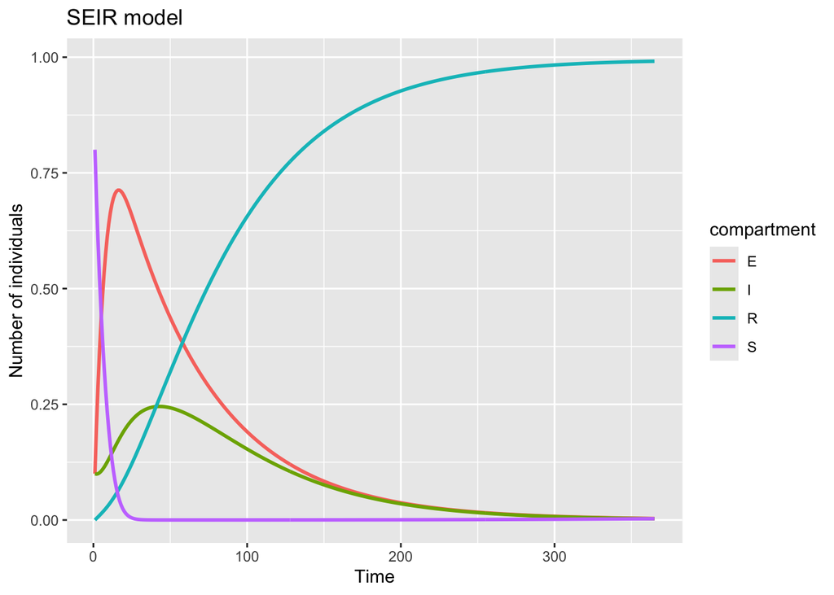

```r
# Load the necessary libraries
library(ggplot2)
library(tidyr)
# Create data for ggplot2 by reshaping
results_long <- seir_results |>
  pivot_longer(
    cols = -time,
    names_to = "compartment",
    values_to = "value"
  )

seir_plot <- ggplot(
  data = results_long,
  aes(
    x = time,
    y = value,
    color = compartment
  )
  ) +
  geom_line(linewidth = 1) +
  labs(
    title = "SEIR model",
    x = "Time",
    y = "Number of individuals"
  )
plot(seir_plot)
```

## Exercise

Example

- Change beta to 0.0003

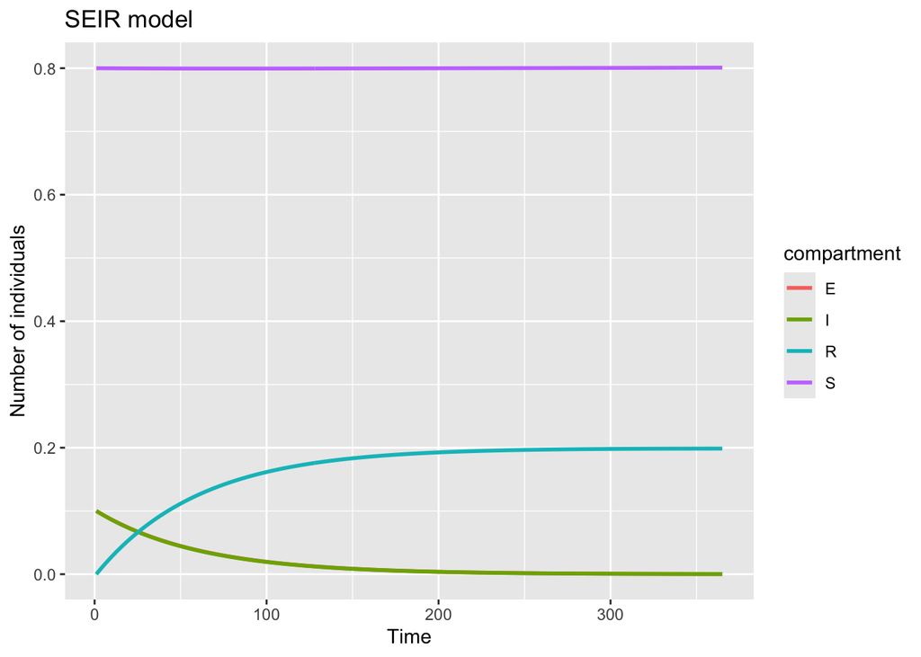

```r
# Load the necessary libraries
library(ggplot2)
library(tidyr)
library(deSolve)
# 1. Define the SEIR model
seir_model <- function(t, y, parms) {
  with(as.list(c(y, parms)), {
    dS <- mu * N - beta * S * I - mu * S
    dE <- beta * S * I - sigma * E - mu * E
    dI <- sigma * E - gamma * I - mu * I
    dR <- gamma * I - mu * R
    return(list(c(dS, dE, dI, dR)))
  })
}
# Set parameter values
beta <- 0.0003
sigma <- 1 / 60
gamma <- 1 / 30
mu <- 774835 / (65640000 * 365)
params <- c(beta, sigma, gamma, mu)

# Initial values
N <- 1
E_0 <- 0.1
I_0 <- 0.1
R_0 <- 0
inits <- c(S = N - (E_0 + I_0 + R_0), E = E_0, I = I_0, R = R_0)

dt <- 1:365
# Solve the model

seir_results <- deSolve::lsoda(
  y = inits,
  times = dt,
  func = seir_model,
  parms = params
)

seir_results <- as.data.frame(seir_results)

# Create data for ggplot2 by reshaping
results_long <- seir_results |>
  pivot_longer(
    cols = -time,
    names_to = "compartment",
    values_to = "value"
  )

seir_plot <- ggplot(
  data = results_long,
  aes(
    x = time,
    y = value,
    color = compartment
  )
) +
  geom_line(linewidth = 1) +
  labs(
    title = "SEIR model",
    x = "Time",
    y = "Number of individuals"
  )
plot(seir_plot)
```

- Can you interpret the plot?

The S compartment is not changing.

- What influence does the birth and death rate have on the dynamics of the model?
- What happens if the birth and death rate is set to zero?
- What happens if the birth and death rate is set to a very high value?
- What happens if the birth and death rate is set to a value higher than the recovery rate?